# Modeling Quality of Suggestions

##### Decision Tree Training Data

```r
pred_2_train <- predict(tree_pruned, newdata = df_1[train_ind,], type="class")

y_train <- df_1[train_ind, "Recommended"]

pruned_cm_train <- caret::confusionMatrix(positive = "1", pred_2_train, as.factor(y_train))

print(pruned_cm_train)
```

```
## Confusion Matrix and Statistics
##
##           Reference
## Prediction     0     1
##          0 11947   118
##          1   783  8262
##
##                Accuracy : 0.9573
##                  95% CI : (0.9545, 0.96)
##     No Information Rate : 0.603
##     P-Value [Acc > NIR] : < 2.2e-16
##
##                   Kappa : 0.912
##
##  Mcnemar's Test P-Value : < 2.2e-16
##
##             Sensitivity : 0.9859
##             Specificity : 0.9385
##          Pos Pred Value : 0.9134
##          Neg Pred Value : 0.9902
##              Prevalence : 0.3970
##          Detection Rate : 0.3914
##    Detection Prevalence : 0.4285
##       Balanced Accuracy : 0.9622
##
##        'Positive' Class : 1
##
```

```r
pruned_cm_mcr_train <- (sum(pruned_cm_train$table)-(sum(diag(pruned_cm_train$table))))/sum(pruned_cm_train$table) *100

print(pruned_cm_mcr_train)
```

```
## [1] 4.268119
```

-*The mis-classification rate is for the decision tree is 4.26811937470393%.*

```r
pruned.prob_train <- predict(tree_pruned, newdata = df_1[train_ind,])[,2]

pruned.roc_train <- roc(response = y_train, predictor = pruned.prob_train)
```

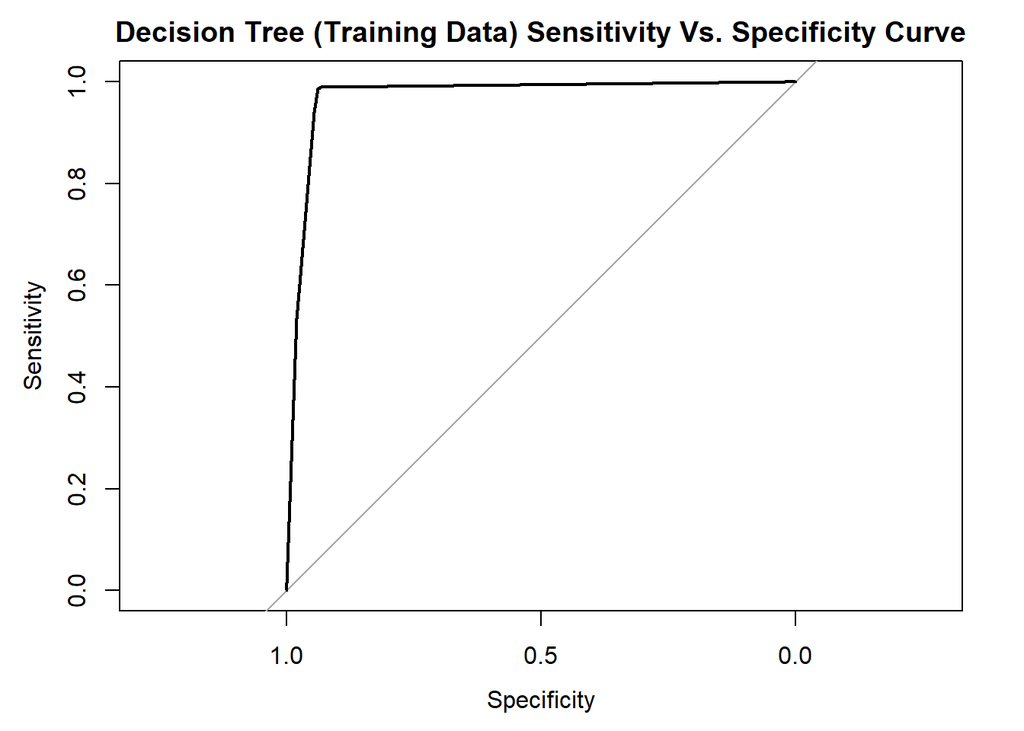

```r
plot(pruned.roc_train, main = "Decision Tree (Training Data) Sensitivity Vs. Specificity Curve")
```

```r
tree_prediction_train <- predict(tree_pruned, newdata = df_1[train_ind,], type = "prob")[,2]

pred_tree_train <-prediction(tree_prediction_train, df_1[train_ind,]$Recommended)
perf_tree_train <- ROCR::performance(pred_tree_train,"auc")
perf_tree_train <- perf_tree_train@y.values[[1]]

perf_tree_train
```

```
## [1] 0.9708296
```

-*Based on the decision tree (Training Data Set), AUC is higher the threshold (0.5), which is 0.97. In other words, it might be a good model to do the prediction in our data set.*

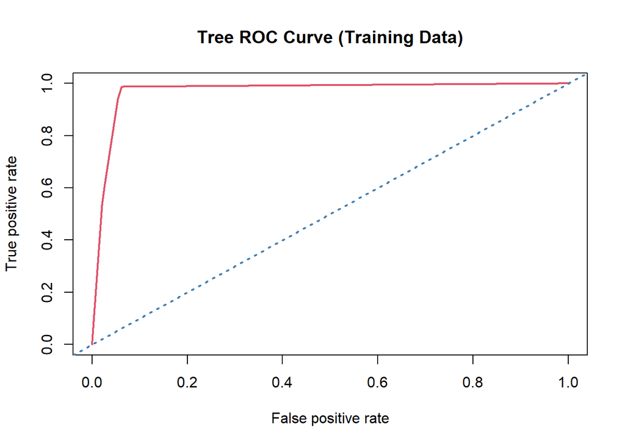

```r
performance_tree_train <- ROCR::performance(pred_tree_train, "tpr","fpr")

Tree_ROC_train <- plot(performance_tree_train, main = "Tree ROC Curve (Training Data)",col = 2,lwd = 2)
abline(a = 0,b = 1,lwd = 2,lty = 3,col = "steelblue")
```

```r
Tree_ROC_train
```

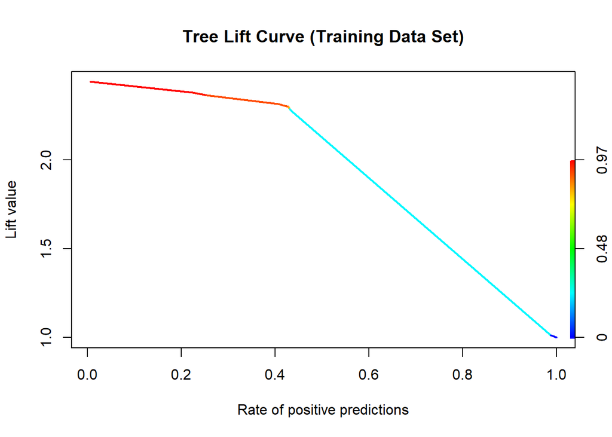

```r
perf_tree_lift_train <- ROCR::performance(pred_tree_train, "lift", "rpp")

plot(perf_tree_lift_train, main = "Tree Lift Curve (Training Data Set)", col = 2, lwd = 2, colorize=TRUE)
```

##### Decision Tree (Testing Data)

```r
pred_2 <- predict(tree_pruned, newdata = df_1[-train_ind,], type="class")

y <- df_1[-train_ind, "Recommended"]

pruned_cm <- caret::confusionMatrix(positive = "1", pred_2, as.factor(y))

print(pruned_cm)
```

```
## Confusion Matrix and Statistics
##
##           Reference
## Prediction    0    1
##          0 2965   36
##          1  172 2105
##
##                Accuracy : 0.9606
##                  95% CI : (0.955, 0.9657)
##     No Information Rate : 0.5944
##     P-Value [Acc > NIR] : < 2.2e-16
##
##                   Kappa : 0.9191
##
##  Mcnemar's Test P-Value : < 2.2e-16
##
##             Sensitivity : 0.9832
##             Specificity : 0.9452
##          Pos Pred Value : 0.9245
##          Neg Pred Value : 0.9880
##              Prevalence : 0.4056
##          Detection Rate : 0.3988
##    Detection Prevalence : 0.4314
##       Balanced Accuracy : 0.9642
##
##        'Positive' Class : 1
##
```

```r
pruned_cm_mcr <- (sum(pruned_cm$table)-(sum(diag(pruned_cm$table))))/sum(pruned_cm$table) *100
pruned_cm_mcr
```

```
## [1] 3.940887
```

-*The mis-classification rate is for the decision tree (Testing Data Set) is 3.94088669950739%.*

```r
pruned.prob <- predict(tree_pruned, newdata = df_1[-train_ind,])[,2]

pruned.roc <- roc(response = y, predictor = pruned.prob)
```

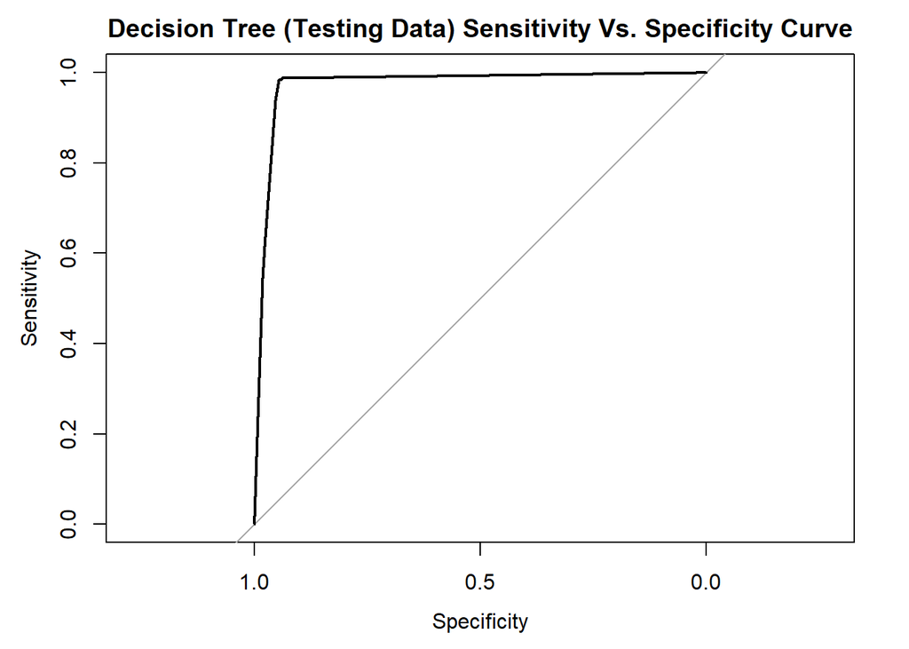

```r
plot(pruned.roc, main = "Decision Tree (Testing Data) Sensitivity Vs. Specificity Curve")
```

```r
tree_prediction <- predict(tree_pruned, newdata = df_1[-train_ind,], type = "prob")[,2]

pred_tree <-prediction(tree_prediction,df_1[-train_ind,]$Recommended)
perf_tree <- ROCR::performance(pred_tree,"auc")
perf_tree <- perf_tree@y.values[[1]]

perf_tree
```

```
## [1] 0.9736748
```

-*Based on the decision tree (Testing Data Set), AUC is higher the threshold (0.5), which is 0.973. In other words, it might be a good model to do the prediction in our data set.*

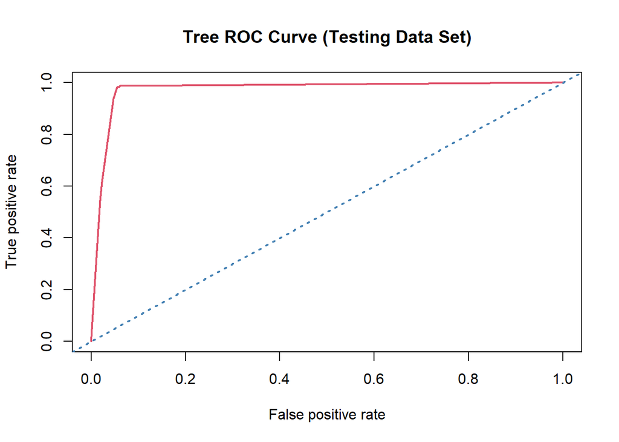

```r
performance_tree <- ROCR::performance(pred_tree, "tpr","fpr")

Tree_ROC <- plot(performance_tree,main = "Tree ROC Curve (Testing Data Set)",col = 2,lwd = 2)
abline(a = 0,b = 1,lwd = 2,lty = 3,col = "steelblue")
```

```r
Tree_ROC
```

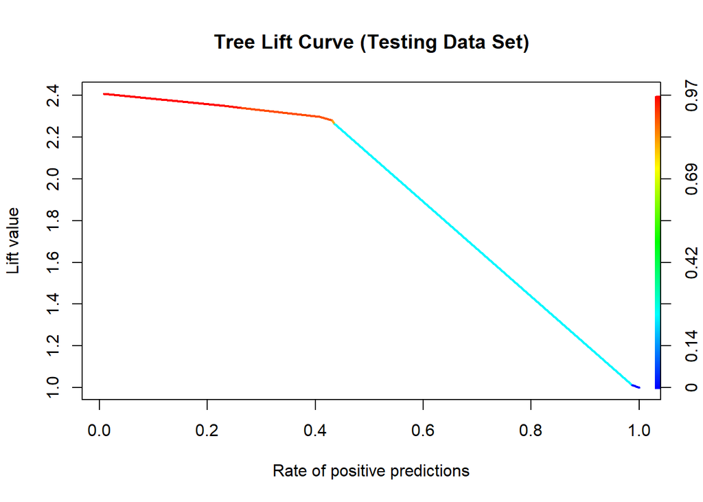

```r
perf_tree_lift <- ROCR::performance(pred_tree, "lift", "rpp")

plot(perf_tree_lift, main = "Tree Lift Curve (Testing Data Set)", col = 2, lwd = 2, colorize=TRUE)
```

-*Based on Decision Tree Lift Curve (Testing Data Set), these employees would correspond with 2.4, which is called the “Maximum Lift point”. The general rule is that the higher this point is, the better our model is performing, as a lot of real positive labels in a proportion of our population which has a very high probability of being positive (which we know that because we have ordered the data points in this manner).*

### Naive Bayes Model

#### Now we will train and test a Naive Bayes model.

```r
nb_model <- NaiveBayes(as.factor(Recommended)~., data = train,  usekernel = TRUE)


summary(nb_model)
```

```
##           Length Class      Mode
## apriori   2      table      numeric
## tables    7      -none-     list
## levels    2      -none-     character
## call      4      -none-     call
## x         7      data.frame list
## usekernel 1      -none-     logical
## varnames  7      -none-     character
```

##### Naive Bayes (Training Data)

```r
pred_nb <- predict(nb_model, newdata = train, type="class")$class

d <- as.numeric(unlist(pred_nb))  > 0.5

d <- ifelse(d == "TRUE", 1, 0)

cm_nb <- confusionMatrix(data = as.factor(d), reference = as.factor(train$Recommended))

cm_nb
```

```
## Confusion Matrix and Statistics
##
##           Reference
## Prediction     0     1
##          0     0     0
##          1 12730  8380
##
##                Accuracy : 0.397
##                  95% CI : (0.3904, 0.4036)
##     No Information Rate : 0.603
##     P-Value [Acc > NIR] : 1
##
##                   Kappa : 0
##
##  Mcnemar's Test P-Value : <2e-16
##
##             Sensitivity : 0.000
##             Specificity : 1.000
##          Pos Pred Value :   NaN
##          Neg Pred Value : 0.397
##              Prevalence : 0.603
##          Detection Rate : 0.000
##    Detection Prevalence : 0.000
##       Balanced Accuracy : 0.500
##
##        'Positive' Class : 0
##
```

```r
# mis-classification rate
round(mean(d != train$Recommended),3)
```

```
## [1] 0.603
```

-*The mis-classification rate is for the Navie Bayes is 0.603*

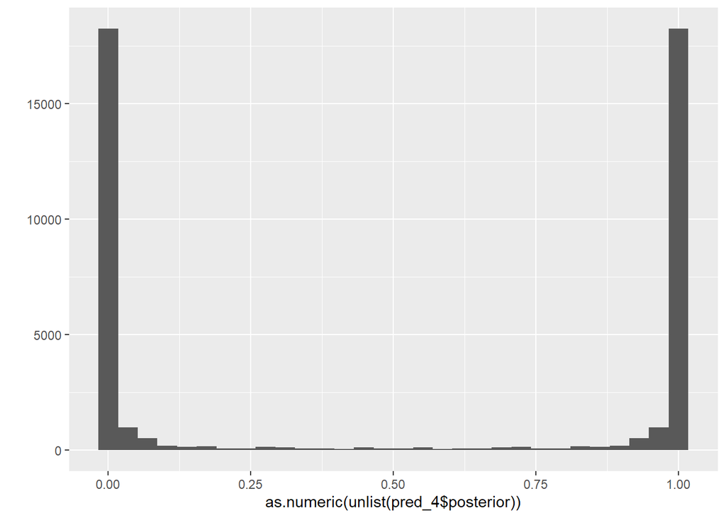

```r
pred_4 <- predict(nb_model, train, type = "raw")

qplot(x=as.numeric(unlist(pred_4$posterior)), geom="histogram")
```

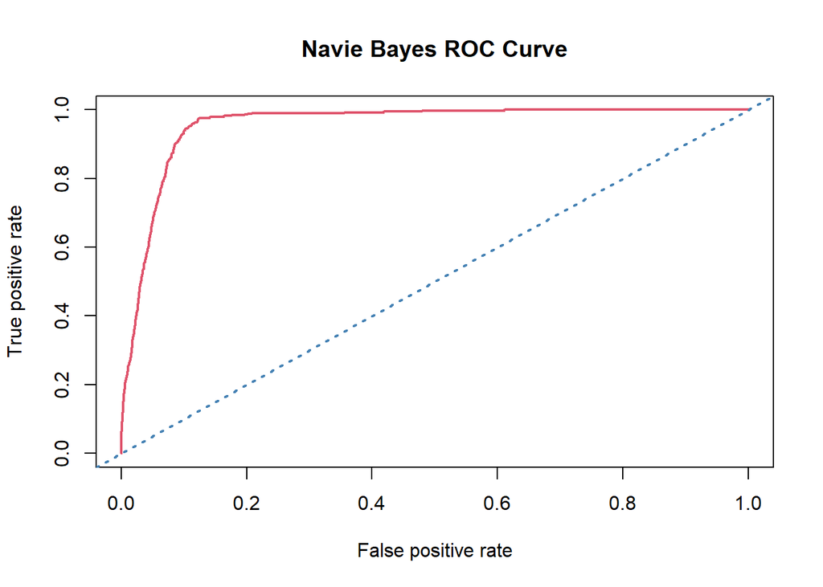

```r
prediction_3 <- prediction(pred_4$posterior[,2], train$Recommended)
performance_3 <- ROCR::performance(prediction_3, "tpr","fpr")

NB_ROC <- plot(performance_3,main = "Navie Bayes ROC Curve",col = 2,lwd = 2)
abline(a = 0,b = 1,lwd = 2,lty = 3,col = "steelblue")
```

```r
NB_ROC
```

```r
AUC_4 <- ROCR::performance(prediction_3, measure = "auc")
AUC_4 <- AUC_4@y.values[[1]]

AUC_4
```

```
## [1] 0.9568434
```

-*Based on Navie Bayes training data AUC & ROC curve, AUC is 0.95, which is above the threshold (0.5), it might be a good choice to use this model predict our data set.*

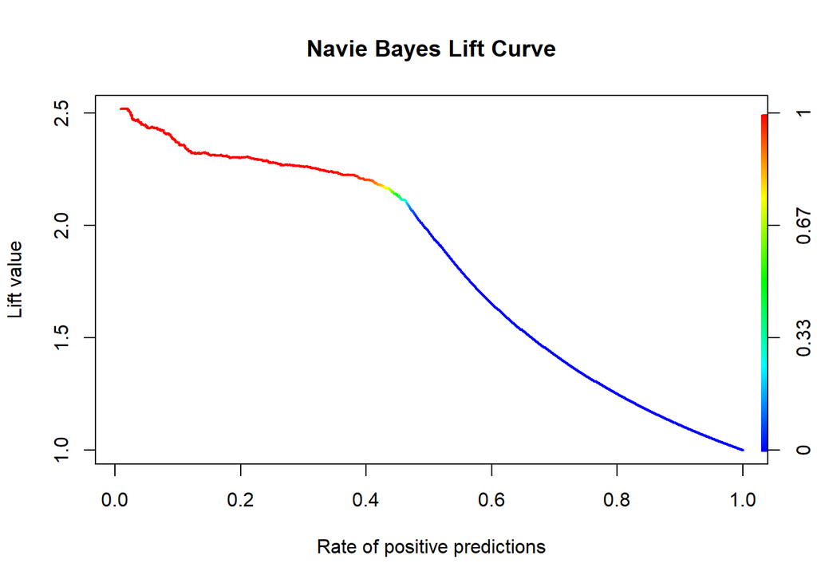

```r
perf_nb_lift <- ROCR::performance(prediction_3, "lift", "rpp")

plot(perf_nb_lift, main = "Navie Bayes Lift Curve", col = 2, lwd = 2, colorize=TRUE)
```

-*Based on Navie Bayes training data Lift Curve, these employees would correspond with 2.5, which is called the “Maximum Lift point”. The general rule is that the higher this point is, the better our model is performing, as a lot of real positive labels in a proportion of our population which has a very high probability of being positive (which we know that because we have ordered the data points in this manner).*

##### Navie Bayes (Testing Data)

```r
pred_nb_1 <- predict(nb_model, newdata = test, type="class")$class

d_1 <- as.numeric(unlist(pred_nb_1))  > 0.5

d_1 <- ifelse(d_1 == "TRUE", 1, 0)

cm_nb_1 <- confusionMatrix(data = as.factor(d_1), reference = as.factor(test$Recommended))

cm_nb_1
```

```
## Confusion Matrix and Statistics
##
##           Reference
## Prediction    0    1
##          0    0    0
##          1 3137 2141
##
##                Accuracy : 0.4056
##                  95% CI : (0.3924, 0.419)
##     No Information Rate : 0.5944
##     P-Value [Acc > NIR] : 1
##
##                   Kappa : 0
##
##  Mcnemar's Test P-Value : <2e-16
##
##             Sensitivity : 0.0000
##             Specificity : 1.0000
##          Pos Pred Value :    NaN
##          Neg Pred Value : 0.4056
##              Prevalence : 0.5944
##          Detection Rate : 0.0000
##    Detection Prevalence : 0.0000
##       Balanced Accuracy : 0.5000
##
##        'Positive' Class : 0
##
```

```r
# mis-classification rate
round(mean(d_1 != test$Recommended),3)
```

```
## [1] 0.594
```

-*The testing data mis-classification rate is for the Navie Bayes is 0.594*

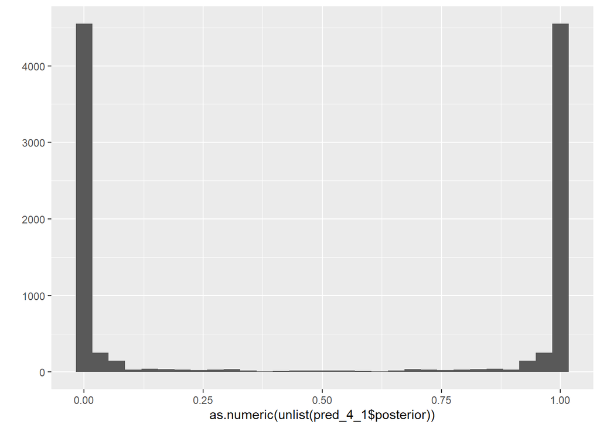

```r
pred_4_1 <- predict(nb_model, test, type = "raw")

qplot(x=as.numeric(unlist(pred_4_1$posterior)), geom="histogram")
```

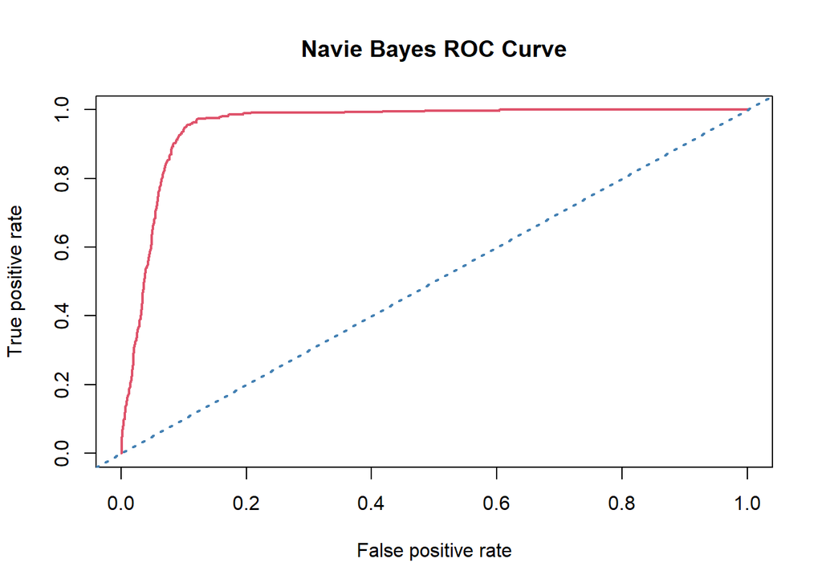

```r
prediction_3_1 <- prediction(pred_4_1$posterior[,2], test$Recommended)
performance_3_1 <- ROCR::performance(prediction_3_1, "tpr","fpr")

NB_ROC_1 <- plot(performance_3_1,main = "Navie Bayes ROC Curve",col = 2,lwd = 2)
abline(a = 0,b = 1,lwd = 2,lty = 3,col = "steelblue")
```

```r
NB_ROC_1
```

```r
AUC_4_1 <- ROCR::performance(prediction_3_1, measure = "auc")
AUC_4_1 <- AUC_4_1@y.values[[1]]

AUC_4_1
```

```
## [1] 0.9541018
```

-*Based on Navie Bayes testing data AUC & ROC curve, AUC is 0.95, which is above the threshold (0.5), it might be a good choice to use this model predict our data set.*

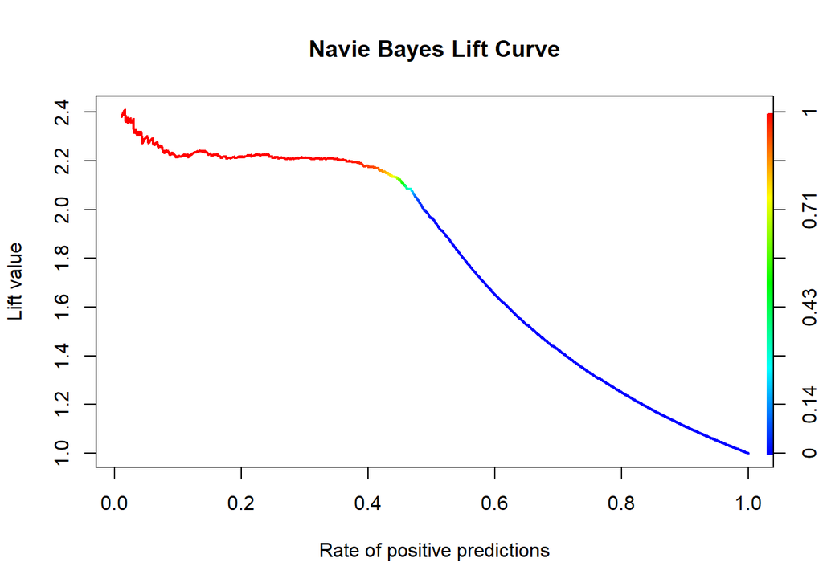

```r
perf_nb_lift_1 <- ROCR::performance(prediction_3_1, "lift", "rpp")

plot(perf_nb_lift_1, main = "Navie Bayes Lift Curve", col = 2, lwd = 2, colorize=TRUE)
```

-*Based on Navie Bayes testing data Lift Curve, these employees would correspond with 2.4, which is called the “Maximum Lift point”. The general rule is that the higher this point is, the better our model is performing, as a lot of real positive labels in a proportion of our population which has a very high probability of being positive (which we know that because we have ordered the data points in this manner).*

```r
LOG_ROC_1 <- roc(train$Recommended, pred_1)
NB_ROC_1 <- roc(train$Recommended, pred_4$posterior[,2])
Tree_ROC_1 <- roc(df_1[-train_ind,]$Recommended, tree_prediction)
```

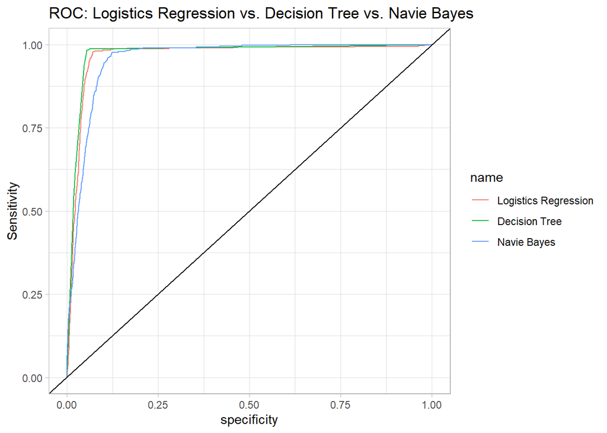

```r
ROC_list <- list("Logistics Regression" = LOG_ROC_1, "Decision Tree" = Tree_ROC_1, "Navie Bayes" = NB_ROC_1)


Combine_ROC <- ggroc(ROC_list, legacy.axes = TRUE)+
  geom_abline()+
  theme_light()+
  ggtitle("ROC: Logistics Regression vs. Decision Tree vs. Navie Bayes")+
  labs(x = "specificity", y = "Sensitivity")

Combine_ROC
```

-*Based on the ROC curve, it seems that the Decision Tree has the highest AUC amongst the models we created, which means that in this case, the Decision Tree is the best way to predict and model on our data set.*

## Conclusion

As we just saw, for this dataset and problem, the Decision Tree appears to be the best way to predict recommended suggestions.

With that said, we believe there are steps that can be taken to decrease the misclassification rate, thereby increasing the accuracy of our model. For example, in conjunction with our IT department we could collect additional information or attributes that would be useful in our models. For example, the following attributes could be very useful:

- Department/Unit/Functional area the employee works in the organization.  
  This information could be useful to give context to the suggestion. For example, if someone in IT were to make a suggestion that HR needed to hire more employees that would be different than someone in HR making that same suggestion as someone in HR would have more information on budget and the process.
- Suggestion Type  
  This information would again be helpful due to the additional context. This information would provide another way the suggestions could be classified. For example, maybe whether or not a suggestion is recommended regarding software is better predicted by the numbers of votes while HR related suggestions are better predicted by the number of views or the tenure of the employee.
- If the employee is in a management position  
  If this attribute was added, it would once again provide additional insight. This could be beneficial because maybe management is inputting suggestions that they made out of feedback from their employees. If that is the case, then maybe suggestions made by management have a higher likelihood of being liked by other employees and also being marked as recommended.

Based off the models we have created, we believe it would be very possible to build a completely automated suggestion ranking system. No matter which model we choose, a ranking could easily be inputted into a system as an algorithm. If management decides to move forward with our decision tree model, since it had the highest accuracy level, that could be inputted as an algorithm. The algorithm would be able to compute a the probability that the suggestion would be recommended given information about the employee who made the suggestion and other metrics. Furthermore, lets suppose the company has a SharePoint list that allows employees to make suggestions and interact with previous suggestions. An initial ranking could be computed based on the initial information provided. And as employees interact with the suggestion, the probability that the suggestion would be recommended would be updated. With a method like this, the employees who review the suggestions would be able to get real time information regarding rankings. And if a tool like SharePoint was utilized, the employees reviewing the suggestions could even create a view that easily sorts the suggestions by rankings.